# Schéma : pagila (films)

pagila, film, relationnel, pattes de corbeau, crowfoot

pagila

crowfoot

DDL

Published

September 20, 2024

Présentation de la partie `film` du schéma `pagila`, pour l’entrainement à PostGres.

- **L3 MIASHS/Ingémath**
- **[Université Paris Cité](https://www.u-paris.fr)**
- Année 2024-2025
- [Course Homepage](https://s-v-b.github.io/MA15Y030/)
- [Moodle](https://moodle.u-paris.fr/course/view.php?id=2313)

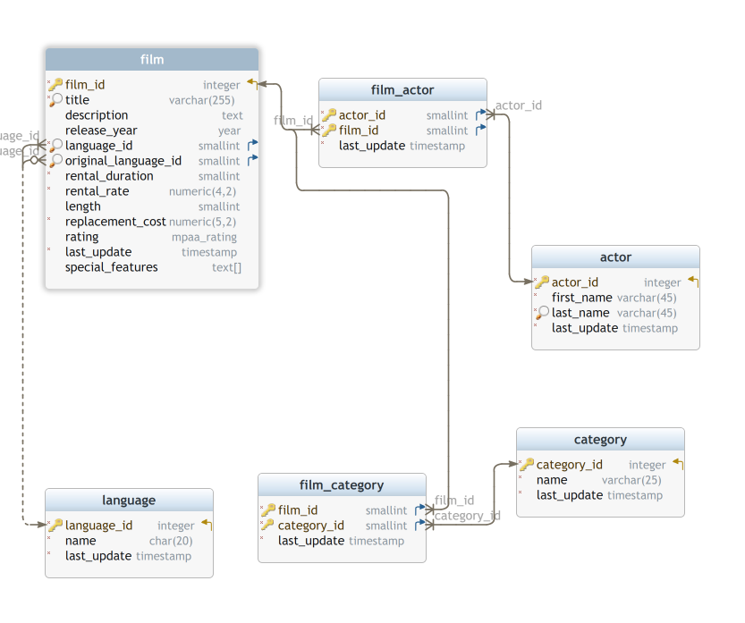

Schema pagila créé par [DbSchema](https://dbschema.com)

## Contexte

Description de quelques tables from the `pagila` database, spécifiquement les tables liées au catalogue de filmss (sans considérer les tables liées au fichier client, à la gestion des locations, aux magasins).

[Pagemaison de la base de données `pagila`](https://github.com/devrimgunduz/pagila).

[Pagemaison de la base de données `sakila`](https://dev.mysql.com/doc/sakila/en/)

## Table pagila.actor

| Idx | Name | Data Type |
| --- | --- | --- |
| * 🔑 ⬋ | actor_id | integer DEFAULT nextval(‘pagila.actor_actor_id_seq’::regclass) |
| * | first_name | varchar(45) |
| * 🔎 | last_name | varchar(45) |
| * | last_update | timestamp DEFAULT now() |

`actor_id` sert de clé primaire. Noter le mécanisme de génération de nouvelles clés grâce au comportment par défaut et à l’usage de la fonction `nextval()` opérant sur une séquence associée à la table `actor`.

La colonne `last_update` sert à dater les mises à jour.

## Table pagila.category

| Idx | Name | Data Type |
| --- | --- | --- |
| * 🔑 ⬋ | category_id | integer DEFAULT nextval(‘pagila.category_category_id_seq’::regclass) |
| * | name | varchar(25) |
| * | last_update | timestamp DEFAULT now() |

## Table pagila.film

| Idx | Name | Data Type |
| --- | --- | --- |
| * 🔑 ⬋ | film_id | integer DEFAULT nextval(‘pagila.film_film_id_seq’::regclass) |
| * 🔎 | title | varchar(255) |
|  | description | text |
|  | release_year | year |
| * 🔎 ⬈ | language_id | smallint |
| 🔎 ⬈ | original_language_id | smallint |
| * | rental_duration | smallint DEFAULT 3 |
| * | rental_rate | numeric(4,2) DEFAULT 4.99 |
|  | length | smallint |
| * | replacement_cost | numeric(5,2) DEFAULT 19.99 |
|  | rating | mpaa_rating DEFAULT ‘G’::pagila.mpaa_rating |
| * | last_update | timestamp DEFAULT now() |
|  | special_features | text[] |

##### Foreign Keys

| Type | Name | On |
| --- | --- | --- |
|  | film_original_language_id_fkey | ( original_language_id ) ref pagila.language (language_id) |
|  | film_language_id_fkey | ( language_id ) ref pagila.language (language_id) |

Un film est censé n’avoir qu’une seule langue originale. L’association *film a pour langue orginale la langue xxx* est de un vers plusieurs. On peut la représenter à l’aide d’un attribut dans la table `film`.

## Table pagila.film_actor

| Idx | Name | Data Type |
| --- | --- | --- |
| * 🔑 ⬈ | actor_id | smallint |
| * 🔑 ⬈ | film_id | smallint |
| * | last_update | timestamp DEFAULT now() |

C’est une table intermédiaire qui permet de représenter/traduire l’association plusieurs à plusieurs *acteur joue dans film*.

##### Foreign Keys

| Type | Name | On |
| --- | --- | --- |
|  | film_actor_film_id_fkey | ( film_id ) ref pagila.film (film_id) |
|  | film_actor_actor_id_fkey | ( actor_id ) ref pagila.actor (actor_id) |

## Table pagila.film_category

| Idx | Name | Data Type |
| --- | --- | --- |
| * 🔑 ⬈ | film_id | smallint |
| * 🔑 ⬈ | category_id | smallint |
| * | last_update | timestamp DEFAULT now() |

##### Foreign Keys

| Type | Name | On |
| --- | --- | --- |
|  | film_category_film_id_fkey | ( film_id ) ref pagila.film (film_id) |
|  | film_category_category_id_fkey | ( category_id ) ref pagila.category (category_id) |

C’est une table intermédiaire qui permet de représenter/traduire l’association plusieurs à plusieurs *film relève de catégorie*.

## Table pagila.language

| Idx | Name | Data Type |
| --- | --- | --- |
| * 🔑 ⬋ | language_id | integer DEFAULT nextval(‘pagila.language_language_id_seq’::regclass) |
| * | name | char(20) |
| * | last_update | timestamp DEFAULT now() |